# Analiza pandemii COVID-19 w Polsce w czasie rzeczywistym

### **Rafał J. Mostowy**

#### Małopolskie Centrum Biotechnologii Uniwersytetu Jagiellońskiego, Kraków, Polska

#### Data ostatniej aktualizacji: 21/05/2020

#### Adres korespondencyjny: rafal.mostowy@uj.edu.pl

## Wprowadzenie

Pandemia COVID-19 rozpoczęła się w Polsce oficjalnie 4 marca 2020, kiedy to został zarejestrowany i potwierdzony pierwszy przypadek osoby zakażonej wirusem SARS-CoV-2. Pierwsze przypadek śmiertelny został odnotowany 12 marca, a pierwsze poważne obostrzenia rządowe były wprowadzone między 12 a 16 marca. Żeby lepiej zrozumieć dynamikę epidemii COVID-19 w Polsce oraz skuteczność interwencji rządowych postanowiłem posłużyć się podejściem podobnym do wypracowanego przez moich [znajomych z Uniwersytetu w Bernie](https://ispmbern.github.io/covid-19/swiss-epidemic-model/), które opiera się na idei dopasowania [modelu epidemiologicznego typu SEIR](https://en.wikipedia.org/wiki/Compartmental_models_in_epidemiology#The_SEIR_model) do liczby zgłaszanych zgonów u pacjentów COVID-19, argumentując, że takie przypadki mają małe prawdopodobieństwo pominięcia. Dopasowuję ten model do oficjalnych danych Ministerstwa Zdrowia, zebranych i upublicznionych przez pana [Michała Rogalskiego](https://twitter.com/micalrg) pod [tym linkiem](https://docs.google.com/spreadsheets/d/1ierEhD6gcq51HAm433knjnVwey4ZE5DCnu1bW7PRG3E/htmlview#gid=1400401584). Analiza ta jest zaktualizowaną wersją wcześniejszego raportu, w której wprowadziłem zmiany do matematycznego modelu epidemiologicznego oraz najnowsze dane na temat liczby zgonów aż do 20/05/2020. Raport ten można przeczytać w wersji [polskiej](https://rmostowy.github.io/covid-19/prognoza-polska) oraz [angielskiej](https://rmostowy.github.io/covid-19/projections-poland). Szczegóły metodologii są dostępne w języku angielskim [tutaj](https://rmostowy.github.io/covid-19/methodology). Kod i dane użyte w tej analizie są dostępne [tutaj](https://github.com/rmostowy/rmostowy.github.io/tree/master/covid-19/code/v2).

## Wyniki

Używając takiego podejścia, na dzień dzisiejszy szacuję następujące parametry epidemii COVID-19 w Polsce. Przed wprowadzeniem obostrzeń rządowych bazowy współczynnik reprodukcji wirusa $R_0$ wynosił 6.37 (95% przedział ufności statystycznej: 4.77 - 8.44), a polska epidemia została zasiana 26/02/2020 (95% CI: 19/02/2020 - 29/02/2020). Obostrzenia rządowe zredukowały współczynnik reprodukcji o 85% (95% CI: 80% - 89%, skutkując w efektywny współczynnik reprodukcji $R(t)$ równy 0.948 (95% CI: 0.913 - 0.98). **Wykres 1** pokazuje szacunki współczynnika $R$ w czasie, sugerując że ma on trend spadkowy. Używając tych szacunków, możemy prognozować wpływ epidemii na stan służby zdrowia w Polsce rzutując szacowaną obecnie dynamikę epidemii na najbliższe tygodnie i miesiące (**Wykres 2**). Rzutowanie takie zakłada jednak, że parametery epidemii się nie zmienią przy napływie nowych danych oraz zmieniających się warunkach atmosferycznych, co jest mało prawdopodobne. Dlatego **rzuty pokazane na Wykresie 2 nie powinny być interpretowane jako prognoza epidemii COVID-19 w Polsce**, tylko jako możliwy wpływ epidemii na służbę zdrowia jeżeli dynamika choroby pozostanie taka, jak uchwycona przez model matematyczny na dzień 21/05/2020.

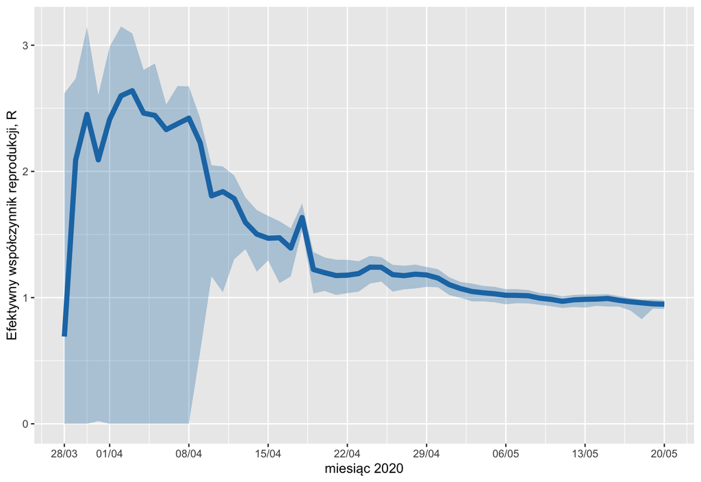

**Wykres 1. Szacunki efektywnego współczynnika reprodukcji, $R$, w czasie.** Wykres pokazuje szacowaną wartość efektywnego współczynnika reprodukcji, $R$, w zależności od daty ostatniego punktu danych. Ciemna linia oznacza szacowaną wartość, a niebieski obszar oznacza 95% przedział ufności statystycznej.

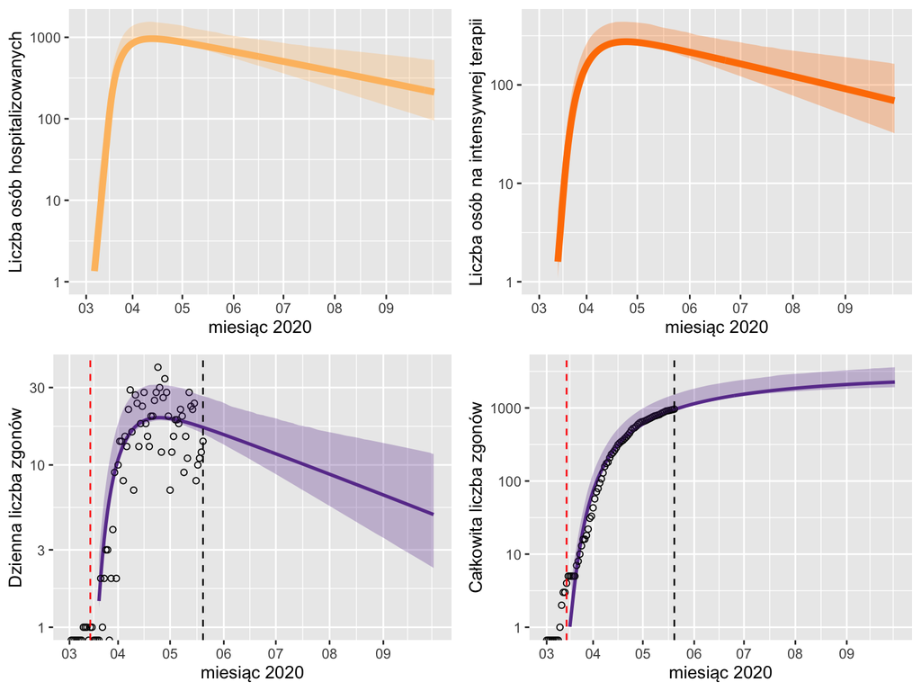

**Wykres 2. Możliwy scenariusz wpływu epidemii na służbę zdrowia w Polsce.** Liczba osób hospitalizowanych (jasno pomarańczowy), liczba osób na oddziałach intensywnej terapii (ciemno-pomarańczowy), dzienna liczba zgonów oraz całkowita liczba zgonów (fioletowy) w czase, zakładając że epidemia COVID-19 w Polsce będzie miała współczynniki takie jak oszacowano z danych aż do 20/05/2020. Kolorowy obszar oznacza 95% przedział ufności statystycznej. Czerwona linia przerywana pokazuje czas wprowadzenia obostrzeń rządowych (zakładam dzień 16/03), a czarna przerywana linia oznacza czas ostatniego punktu danych (20/05/2020).